# NASP-ESOL - Social Network Analysis

Hands-on sessions

Federico Bianchi

# 1 Introduction

- This is a notebook for hands-on sessions of the Social Network Analysis course for Ph.D. students of the NASP doctoral school, University of Milan (Italy).
- Analysed data are taken from @bianchi-coworking

# 2 Collaboration

## 2.1 Loading data

- Now, we need to import data on *collaboration* relationships.
- In order to let `R` find the data, we need to move the data file to the same directory where our Rstudio project is located (i.e., the *working directory*)

If you don’t remember what working directory you’re in:

```r
getwd()
```

```
## [1] "/Users/federico/Desktop/lab"
```

- Let’s inspect the data structure: we could either open the file outside Rstudio or even from within
- It’s a .txt file. What do you see?
- It’s an **adjacency matrix** (see [slides](https://federico-bianchi.github.io/teaching/))
- Values are 0 and 1 and are separated by a tab (`\t`)
- In order to load it, we need a function to read a table data structure.
- `read.table` is classic R, while `readr::read_delim` is faster. Let’s load the `readr` package, included in the `tidyverse`.

```r
# library(readr)
library(tidyverse)
```

Now we can inspect the `read_delim` function in the console, by hitting `?read_delim`

```r
?read_delim
```

What information do we need? * the file name: `collaboration.txt` * the column separator: `"\t"` * whether we have column names: no

Where is my data file?

```r
dir()
```

```
## [1] "collaboration.txt" "data"              "lab_files"
## [4] "lab.html"          "lab.nb.html"       "lab.Rmd"
## [7] "lab.Rproj"         "support.csv"
```

In order to maximise reproducibility, we need the path to be available to all possible colleagues. We can use the `here::here` function, which builds a new path regardless of the original path. Let’s load the `here` package.

```r
library(here)
```

The function `here()` finds my working directory and builds a plausible path towards the specified arguments.

```r
here("data", "collaboration.txt")
```

```
## [1] "/Users/federico/Desktop/lab/data/collaboration.txt"
```

Now we’re ready to load collaboration data as a new object. We can use `read_tsv`, which takes `"\t"` as a default value of the `delim` parameter

```r
here("data", "collaboration.txt") %>%
  read_tsv(col_names = FALSE)
```

| X1 | X2 | X3 | X4 | X5 | X6 | X7 | X8 | X9 | X10 | X11 | X12 | X13 | X14 | X15 | X16 | X17 | X18 | X19 | X20 | X21 | X22 | X23 | X24 | X25 | X26 | X27 | X28 | X29 |
| --- | --- | --- | --- | --- | --- | --- | --- | --- | --- | --- | --- | --- | --- | --- | --- | --- | --- | --- | --- | --- | --- | --- | --- | --- | --- | --- | --- | --- |
| 0 | 0 | 0 | 0 | 0 | 0 | 0 | 0 | 0 | 0 | 0 | 1 | 0 | 0 | 0 | 0 | 0 | 0 | 0 | 0 | 0 | 0 | 0 | 0 | 0 | 0 | 0 | 0 | 0 |
| 0 | 0 | 0 | 1 | 0 | 0 | 1 | 1 | 1 | 1 | 0 | 0 | 1 | 1 | 1 | 1 | 0 | 0 | 0 | 0 | 0 | 0 | 0 | 0 | 0 | 0 | 0 | 0 | 0 |
| 0 | 0 | 0 | 0 | 0 | 1 | 0 | 1 | 1 | 1 | 0 | 0 | 0 | 1 | 0 | 0 | 0 | 0 | 1 | 1 | 0 | 0 | 1 | 0 | 1 | 1 | 1 | 1 | 0 |
| 0 | 1 | 0 | 0 | 0 | 0 | 0 | 0 | 1 | 1 | 0 | 0 | 0 | 1 | 0 | 0 | 0 | 0 | 0 | 0 | 0 | 0 | 0 | 0 | 0 | 0 | 0 | 0 | 0 |
| 0 | 0 | 0 | 0 | 0 | 0 | 0 | 0 | 0 | 0 | 0 | 0 | 0 | 0 | 0 | 0 | 0 | 0 | 0 | 0 | 0 | 0 | 0 | 0 | 0 | 0 | 0 | 0 | 0 |
| 0 | 0 | 1 | 0 | 0 | 0 | 0 | 0 | 1 | 1 | 0 | 0 | 1 | 0 | 1 | 1 | 1 | 0 | 1 | 1 | 0 | 0 | 1 | 0 | 0 | 0 | 0 | 0 | 0 |
| 0 | 1 | 0 | 0 | 0 | 0 | 0 | 0 | 0 | 0 | 0 | 0 | 0 | 0 | 0 | 0 | 0 | 0 | 0 | 0 | 1 | 0 | 0 | 0 | 0 | 0 | 0 | 0 | 0 |
| 0 | 1 | 1 | 0 | 0 | 0 | 0 | 0 | 0 | 1 | 0 | 0 | 0 | 0 | 0 | 0 | 0 | 0 | 1 | 0 | 1 | 0 | 0 | 0 | 0 | 0 | 1 | 1 | 0 |
| 0 | 1 | 1 | 1 | 0 | 1 | 0 | 0 | 0 | 0 | 0 | 0 | 0 | 1 | 0 | 0 | 0 | 0 | 1 | 1 | 0 | 0 | 1 | 0 | 0 | 0 | 0 | 0 | 0 |
| 0 | 1 | 1 | 1 | 0 | 1 | 0 | 1 | 0 | 0 | 0 | 0 | 1 | 0 | 1 | 1 | 0 | 0 | 1 | 1 | 1 | 0 | 1 | 0 | 0 | 1 | 1 | 1 | 0 |

[output cut: 19 more lines]

What kind of object have we stored our data in?

```r
here("data", "collaboration.txt") %>%
  read_tsv(col_names = FALSE) %>%
  class()
```

```
## [1] "spec_tbl_df" "tbl_df"      "tbl"         "data.frame"
```

It’s a `tibble`, the `tidyverse` version of a `data.frame`.

Let’s inspect our data

```r
here("data", "collaboration.txt") %>%
  read_tsv(col_names = FALSE) %>%
  str()
```

```
## spc_tbl_ [29 × 29] (S3: spec_tbl_df/tbl_df/tbl/data.frame)
##  $ X1 : num [1:29] 0 0 0 0 0 0 0 0 0 0 ...
##  $ X2 : num [1:29] 0 0 0 1 0 0 1 1 1 1 ...
##  $ X3 : num [1:29] 0 0 0 0 0 1 0 1 1 1 ...
##  $ X4 : num [1:29] 0 1 0 0 0 0 0 0 1 1 ...
##  $ X5 : num [1:29] 0 0 0 0 0 0 0 0 0 0 ...
##  $ X6 : num [1:29] 0 0 1 0 0 0 0 0 1 1 ...
##  $ X7 : num [1:29] 0 1 0 0 0 0 0 0 0 0 ...
##  $ X8 : num [1:29] 0 1 1 0 0 0 0 0 0 1 ...
##  $ X9 : num [1:29] 0 1 1 1 0 1 0 0 0 0 ...
##  $ X10: num [1:29] 0 1 1 1 0 1 0 1 0 0 ...
##  $ X11: num [1:29] 0 0 0 0 0 0 0 0 0 0 ...
##  $ X12: num [1:29] 1 0 0 0 0 0 0 0 0 0 ...
##  $ X13: num [1:29] 0 1 0 0 0 1 0 0 0 1 ...
##  $ X14: num [1:29] 0 1 1 1 0 0 0 0 1 0 ...
##  $ X15: num [1:29] 0 1 0 0 0 1 0 0 0 1 ...
##  $ X16: num [1:29] 0 1 0 0 0 1 0 0 0 1 ...
##  $ X17: num [1:29] 0 0 0 0 0 1 0 0 0 0 ...
##  $ X18: num [1:29] 0 0 0 0 0 0 0 0 0 0 ...
##  $ X19: num [1:29] 0 0 1 0 0 1 0 1 1 1 ...
##  $ X20: num [1:29] 0 0 1 0 0 1 0 0 1 1 ...
##  $ X21: num [1:29] 0 0 0 0 0 0 1 1 0 1 ...
##  $ X22: num [1:29] 0 0 0 0 0 0 0 0 0 0 ...
##  $ X23: num [1:29] 0 0 1 0 0 1 0 0 1 1 ...
##  $ X24: num [1:29] 0 0 0 0 0 0 0 0 0 0 ...
##  $ X25: num [1:29] 0 0 1 0 0 0 0 0 0 0 ...
##  $ X26: num [1:29] 0 0 1 0 0 0 0 0 0 1 ...
##  $ X27: num [1:29] 0 0 1 0 0 0 0 1 0 1 ...
##  $ X28: num [1:29] 0 0 1 0 0 0 0 1 0 1 ...
##  $ X29: num [1:29] 0 0 0 0 0 0 0 0 0 0 ...
##  - attr(*, "spec")=
##   .. cols(
##   ..   X1 = col_double(),
##   ..   X2 = col_double(),
##   ..   X3 = col_double(),
##   ..   X4 = col_double(),
##   ..   X5 = col_double(),
##   ..   X6 = col_double(),
##   ..   X7 = col_double(),
##   ..   X8 = col_double(),
```

[output cut: 8 more lines]

```
##   ..   X17 = col_double(),
##   ..   X18 = col_double(),
##   ..   X19 = col_double(),
##   ..   X20 = col_double(),
##   ..   X21 = col_double(),
##   ..   X22 = col_double(),
##   ..   X23 = col_double(),
##   ..   X24 = col_double(),
##   ..   X25 = col_double(),
##   ..   X26 = col_double(),
##   ..   X27 = col_double(),
##   ..   X28 = col_double(),
##   ..   X29 = col_double()
##   .. )
##  - attr(*, "problems")=<externalptr>
```

- It’s interpreted as a case-by-variable matrix, with 29 variables.
- Instead, what we need is an adjacency matrix.

```r
here("data", "collaboration.txt") %>%
  read_tsv(col_names = FALSE) %>%
  as.matrix()
```

```
##       X1 X2 X3 X4 X5 X6 X7 X8 X9 X10 X11 X12 X13 X14 X15 X16 X17 X18 X19 X20
##  [1,]  0  0  0  0  0  0  0  0  0   0   0   1   0   0   0   0   0   0   0   0
##  [2,]  0  0  0  1  0  0  1  1  1   1   0   0   1   1   1   1   0   0   0   0
##  [3,]  0  0  0  0  0  1  0  1  1   1   0   0   0   1   0   0   0   0   1   1
##  [4,]  0  1  0  0  0  0  0  0  1   1   0   0   0   1   0   0   0   0   0   0
##  [5,]  0  0  0  0  0  0  0  0  0   0   0   0   0   0   0   0   0   0   0   0
##  [6,]  0  0  1  0  0  0  0  0  1   1   0   0   1   0   1   1   1   0   1   1
##  [7,]  0  1  0  0  0  0  0  0  0   0   0   0   0   0   0   0   0   0   0   0
##  [8,]  0  1  1  0  0  0  0  0  0   1   0   0   0   0   0   0   0   0   1   0
##  [9,]  0  1  1  1  0  1  0  0  0   0   0   0   0   1   0   0   0   0   1   1
## [10,]  0  1  1  1  0  1  0  1  0   0   0   0   1   0   1   1   0   0   1   1
## [11,]  0  0  0  0  0  0  0  0  0   0   0   0   0   0   0   0   0   0   0   0
## [12,]  1  0  0  0  0  0  0  0  0   0   0   0   0   0   0   0   0   0   0   0
## [13,]  0  1  0  0  0  1  0  0  0   1   0   0   0   0   1   1   0   0   0   1
## [14,]  0  1  1  1  0  0  0  0  1   0   0   0   0   0   0   0   0   0   0   0
```

[output cut: 45 more lines]

Now our data are interpreted by `R` as a matrix.

```r
(collab_data <-
  here("data", "collaboration.txt") %>%
  read_tsv(col_names = FALSE) %>%
  as.matrix())
```

```
##       X1 X2 X3 X4 X5 X6 X7 X8 X9 X10 X11 X12 X13 X14 X15 X16 X17 X18 X19 X20
##  [1,]  0  0  0  0  0  0  0  0  0   0   0   1   0   0   0   0   0   0   0   0
##  [2,]  0  0  0  1  0  0  1  1  1   1   0   0   1   1   1   1   0   0   0   0
##  [3,]  0  0  0  0  0  1  0  1  1   1   0   0   0   1   0   0   0   0   1   1
##  [4,]  0  1  0  0  0  0  0  0  1   1   0   0   0   1   0   0   0   0   0   0
##  [5,]  0  0  0  0  0  0  0  0  0   0   0   0   0   0   0   0   0   0   0   0
##  [6,]  0  0  1  0  0  0  0  0  1   1   0   0   1   0   1   1   1   0   1   1
##  [7,]  0  1  0  0  0  0  0  0  0   0   0   0   0   0   0   0   0   0   0   0
##  [8,]  0  1  1  0  0  0  0  0  0   1   0   0   0   0   0   0   0   0   1   0
##  [9,]  0  1  1  1  0  1  0  0  0   0   0   0   0   1   0   0   0   0   1   1
## [10,]  0  1  1  1  0  1  0  1  0   0   0   0   1   0   1   1   0   0   1   1
## [11,]  0  0  0  0  0  0  0  0  0   0   0   0   0   0   0   0   0   0   0   0
## [12,]  1  0  0  0  0  0  0  0  0   0   0   0   0   0   0   0   0   0   0   0
## [13,]  0  1  0  0  0  1  0  0  0   1   0   0   0   0   1   1   0   0   0   1
## [14,]  0  1  1  1  0  0  0  0  1   0   0   0   0   0   0   0   0   0   0   0
```

[output cut: 45 more lines]

## 2.2 From data to graphs

In order to apply some SNA functions, we need to use the `igraph` package, which handles our data as `igraph` objects, to which its functions can be applied

```r
library(igraph)
```

- We have to turn our data into an `igraph` object.
- There’s a series of primitives starting with `graph_from` that can be useful for us
- We need to specify that the matrix should be interpreted as undirected graph

```r
(collab_net <- graph_from_adjacency_matrix(collab_data, mode = "undirected"))
```

```
## IGRAPH c98a2b1 UN-- 29 82 --
## + attr: name (v/c)
## + edges from c98a2b1 (vertex names):
##  [1] X1 --X12 X2 --X4  X2 --X7  X2 --X8  X2 --X9  X2 --X10 X2 --X13 X2 --X14
##  [9] X2 --X15 X2 --X16 X3 --X6  X3 --X8  X3 --X9  X3 --X10 X3 --X14 X3 --X19
## [17] X3 --X20 X3 --X23 X3 --X25 X3 --X26 X3 --X27 X3 --X28 X4 --X9  X4 --X10
## [25] X4 --X14 X6 --X9  X6 --X10 X6 --X13 X6 --X15 X6 --X16 X6 --X17 X6 --X19
## [33] X6 --X20 X6 --X23 X7 --X21 X8 --X10 X8 --X19 X8 --X21 X8 --X27 X8 --X28
## [41] X9 --X14 X9 --X19 X9 --X20 X9 --X23 X10--X13 X10--X15 X10--X16 X10--X19
## [49] X10--X20 X10--X21 X10--X23 X10--X26 X10--X27 X10--X28 X13--X15 X13--X16
## [57] X13--X20 X13--X22 X13--X23 X15--X16 X15--X20 X15--X22 X15--X23 X16--X20
## + ... omitted several edges
```

The summary shows us:

- that the network is undirected and “named” (UN)
- 29 nodes
- 82 links
- the list of the edges

An `igraph` object is a complex R object made of lists

```r
str(collab_net)
```

```
## Class 'igraph'  hidden list of 10
##  $ : num 29
##  $ : logi FALSE
##  $ : num [1:82] 11 3 6 7 8 9 12 13 14 15 ...
##  $ : num [1:82] 0 1 1 1 1 1 1 1 1 1 ...
##  $ : NULL
##  $ : NULL
##  $ : NULL
##  $ : NULL
##  $ :List of 4
##   ..$ : num [1:3] 1 0 1
##   ..$ : Named list()
##   ..$ :List of 1
##   .. ..$ name: chr [1:29] "X1" "X2" "X3" "X4" ...
##   ..$ : Named list()
##  $ :<environment: 0x1347e2888>
```

Network data can be managed more efficiently with the `tidygraph` package, which allows us to apply the `tidyverse` logic on `igraph` objects

```r
library(tidygraph)
```

We can make a `tbl_graph` object, structude into two tables: one for node attributes and one for the edge list.

```r
as_tbl_graph(collab_net)
```

```
## # A tbl_graph: 29 nodes and 82 edges
## #
## # An undirected simple graph with 5 components
## #
## # Node Data: 29 × 1 (active)
##    name
##    <chr>
##  1 X1
##  2 X2
##  3 X3
##  4 X4
##  5 X5
##  6 X6
##  7 X7
##  8 X8
##  9 X9
## 10 X10
## # ℹ 19 more rows
## #
## # Edge Data: 82 × 2
##    from    to
##   <int> <int>
## 1     1    12
## 2     2     4
## 3     2     7
## # ℹ 79 more rows
```

Let’s use the table of node attributes to change the node names

```r
(collab_net <-
  collab_net %>%
  as_tbl_graph() %>%
  activate(nodes) %>%
  mutate(name = as.character(1:vcount(collab_net))))
```

```
## # A tbl_graph: 29 nodes and 82 edges
## #
## # An undirected simple graph with 5 components
## #
## # Node Data: 29 × 1 (active)
##    name
##    <chr>
##  1 1
##  2 2
##  3 3
##  4 4
##  5 5
##  6 6
##  7 7
##  8 8
##  9 9
## 10 10
## # ℹ 19 more rows
## #
## # Edge Data: 82 × 2
##    from    to
##   <int> <int>
## 1     1    12
## 2     2     4
## 3     2     7
## # ℹ 79 more rows
```

Let’s inspect subsets of our network using the edge list

```r
collab_net %>%
  activate(edges) %>%
  filter(to != 10 & from != 10)
```

```
## # A tbl_graph: 29 nodes and 67 edges
## #
## # An undirected simple graph with 6 components
## #
## # Edge Data: 67 × 2 (active)
##     from    to
##    <int> <int>
##  1     1    12
##  2     2     4
##  3     2     7
##  4     2     8
##  5     2     9
##  6     2    13
##  7     2    14
##  8     2    15
##  9     2    16
## 10     3     6
## # ℹ 57 more rows
## #
## # Node Data: 29 × 1
##   name
##   <chr>
## 1 1
## 2 2
## 3 3
## # ℹ 26 more rows
```

## 2.3 Visualization

We can use base `R` visualization but it’s not very efficient

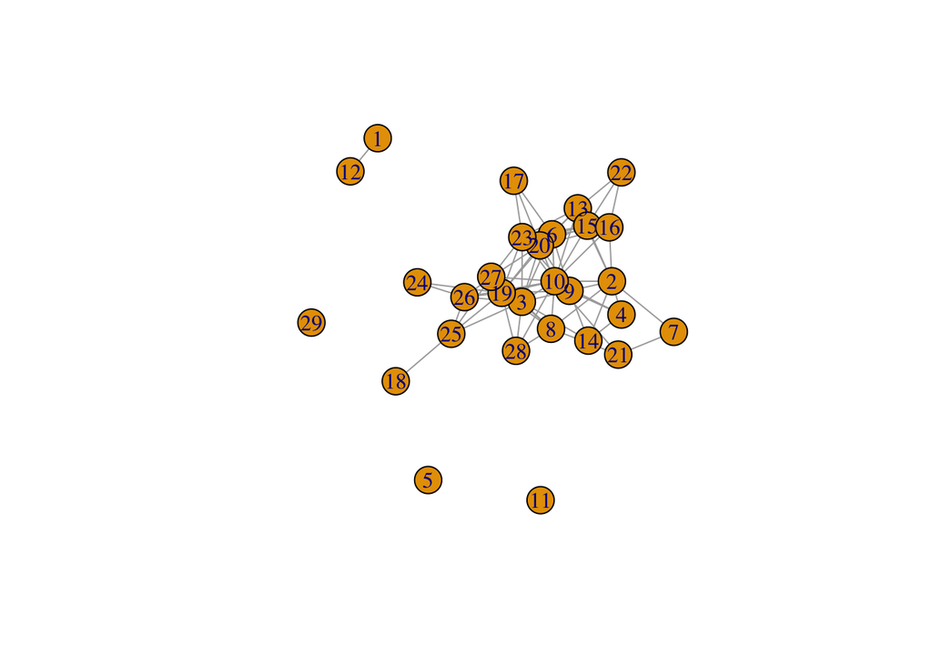

```r
plot(collab_net)
```

More efficient and elegant visualization can be made with the `ggraph` package, which allows us to use `ggplot2` on `igraph` objects

```r
library(ggraph)
```

Here’s a fist attempt with Fruchterman-Rheingold layout

```r
collab_plot <- collab_net %>%
  ggraph(layout = "fr") +
  geom_edge_link(
    colour = "grey30",
    width = .5,
    alpha = .5
  ) +
  geom_node_point(
    size = 2,
    color = "red"
  ) +
  geom_node_text(aes(label = name))
```

## 2.4 Connectivity

A basic *graph-level* network property we could be interested in is how *connected* a network is

Let’s start from the number of edges

```r
ecount(collab_net)
```

```
## [1] 82
```

We can also retrieve the whole list of edges

```r
E(collab_net)
```

```
## + 82/82 edges from c98a2b1 (vertex names):
##  [1] 1 --12 2 --4  2 --7  2 --8  2 --9  2 --10 2 --13 2 --14 2 --15 2 --16
## [11] 3 --6  3 --8  3 --9  3 --10 3 --14 3 --19 3 --20 3 --23 3 --25 3 --26
## [21] 3 --27 3 --28 4 --9  4 --10 4 --14 6 --9  6 --10 6 --13 6 --15 6 --16
## [31] 6 --17 6 --19 6 --20 6 --23 7 --21 8 --10 8 --19 8 --21 8 --27 8 --28
## [41] 9 --14 9 --19 9 --20 9 --23 10--13 10--15 10--16 10--19 10--20 10--21
## [51] 10--23 10--26 10--27 10--28 13--15 13--16 13--20 13--22 13--23 15--16
## [61] 15--20 15--22 15--23 16--20 16--22 17--20 17--23 18--25 19--20 19--23
## [71] 19--24 19--25 19--26 19--27 19--28 20--23 20--27 23--27 24--26 25--26
## [81] 25--27 26--27
```

The number of edges depends on the number of vertices

```r
vcount(collab_net)
```

```
## [1] 29
```

We can also retrieve the list of vertices

```r
V(collab_net)
```

```
## + 29/29 vertices, named, from c98a2b1:
##  [1] 1  2  3  4  5  6  7  8  9  10 11 12 13 14 15 16 17 18 19 20 21 22 23 24 25
## [26] 26 27 28 29
```

### 2.4.1 Density

- In order to infer the level of *connectivity* from the number of edges, we need to compare it to the theoretically maximum value of possible links
- We combine each vertex with all other possible vertices
- Since our network is undirected, we divide by 2, so that we don’t count pairs twice
- We’ll store the calculation output in a new object because we’re going to use it later again and we want to stay [D.R.Y.](https://en.wikipedia.org/wiki/Don%27t_repeat_yourself)

```r
(max_links <- vcount(collab_net) * (vcount(collab_net) - 1) / 2)
```

```
## [1] 406
```

Now, we can calculate *density* as the ratio between the number of actual links and the number of possible links.

```r
(density <- ecount(collab_net) / max_links)
```

```
## [1] 0.2019704
```

Actually, we don’t need to perform this calculation every time. There is a specific function in `igraph`

```r
edge_density(collab_net)
```

```
## [1] 0.2019704
```

# 3 Support

## 3.1 Loading data

- Data on support relationships are stored with a different structure
- It’s an **edgelist** (see [slides](https://federico-bianchi.github.io/teaching/))
- We still need to assign data to a matrix object (not an adjacency matrix, though)

```r
(sup_dat <-
  here("data", "support.csv") %>%
  read_delim(delim = " ", col_names = FALSE) %>%
  as.matrix())
```

```
##        X1    X2
##   [1,] "V1"  "V29"
##   [2,] "V2"  "V4"
##   [3,] "V2"  "V14"
##   [4,] "V2"  "V15"
##   [5,] "V2"  "V28"
##   [6,] "V3"  "V10"
##   [7,] "V3"  "V13"
##   [8,] "V3"  "V15"
##   [9,] "V3"  "V16"
##  [10,] "V3"  "V25"
##  [11,] "V3"  "V26"
##  [12,] "V3"  "V27"
##  [13,] "V4"  "V2"
##  [14,] "V5"  "V24"
```

[output cut: 85 more lines]

## 3.2 From data to graph

```r
(support <- graph_from_edgelist(sup_dat))
```

```
## IGRAPH 21f724c DN-- 28 99 --
## + attr: name (v/c)
## + edges from 21f724c (vertex names):
##  [1] V1 ->V29 V2 ->V4  V2 ->V14 V2 ->V15 V2 ->V28 V3 ->V10 V3 ->V13 V3 ->V15
##  [9] V3 ->V16 V3 ->V25 V3 ->V26 V3 ->V27 V4 ->V2  V5 ->V24 V6 ->V12 V6 ->V13
## [17] V6 ->V15 V6 ->V16 V6 ->V17 V6 ->V20 V6 ->V23 V7 ->V1  V7 ->V12 V8 ->V2
## [25] V8 ->V4  V8 ->V10 V8 ->V13 V8 ->V15 V8 ->V25 V8 ->V27 V8 ->V28 V9 ->V2
## [33] V9 ->V14 V10->V3  V10->V13 V10->V15 V10->V19 V10->V27 V12->V1  V12->V2
## [41] V12->V10 V12->V20 V13->V16 V14->V2  V14->V8  V14->V9  V14->V25 V15->V6
## [49] V15->V10 V15->V13 V15->V16 V15->V22 V16->V13 V16->V15 V16->V22 V17->V6
## [57] V17->V20 V18->V25 V19->V3  V19->V25 V19->V27 V20->V6  V20->V12 V20->V17
## + ... omitted several edges
```

- Why are nodes 28? We were expecting 29
- One of the nodes might be an *isolate*
- It’s always good practice to store the list of edges and the list of nodes in two different objects, then integrate them in a graph object
- The nodes are coded in the edge list file as “V1”, “V2”, …, “V29”
- So, we’ll generate a character vector by combining “V” with numbers between 1-29

```r
sup_edges <- sup_dat
sup_nodes <- paste0("V", 1:29)
```

Now we have a vector of nodes (node list) and a `matrix` of edges (edge list). We can then generate a graph object in a safer way through `graph_from_data_frame`, which takes a node list (vector) and and edge list (matrix) as inputs.

```r
(sup_net <- graph_from_data_frame(d = sup_edges, vertices = sup_nodes))
```

```
## IGRAPH 9af0edf DN-- 29 99 --
## + attr: name (v/c)
## + edges from 9af0edf (vertex names):
##  [1] V1 ->V29 V2 ->V4  V2 ->V14 V2 ->V15 V2 ->V28 V3 ->V10 V3 ->V13 V3 ->V15
##  [9] V3 ->V16 V3 ->V25 V3 ->V26 V3 ->V27 V4 ->V2  V5 ->V24 V6 ->V12 V6 ->V13
## [17] V6 ->V15 V6 ->V16 V6 ->V17 V6 ->V20 V6 ->V23 V7 ->V1  V7 ->V12 V8 ->V2
## [25] V8 ->V4  V8 ->V10 V8 ->V13 V8 ->V15 V8 ->V25 V8 ->V27 V8 ->V28 V9 ->V2
## [33] V9 ->V14 V10->V3  V10->V13 V10->V15 V10->V19 V10->V27 V12->V1  V12->V2
## [41] V12->V10 V12->V20 V13->V16 V14->V2  V14->V8  V14->V9  V14->V25 V15->V6
## [49] V15->V10 V15->V13 V15->V16 V15->V22 V16->V13 V16->V15 V16->V22 V17->V6
## [57] V17->V20 V18->V25 V19->V3  V19->V25 V19->V27 V20->V6  V20->V12 V20->V17
## + ... omitted several edges
```

## 3.3 Connectivity

Calculating density:

```r
edge_density(sup_net)
```

```
## [1] 0.1219212
```